# PersonAlytics Software Design Document

Stephen Tueller

2018-08-23

**SDD Revisions**

| Date | Description | Revision | Editor |
| --- | --- | --- | --- |
| 20180820 | Document Creation | 0 | Stephen Tueller |

# Introduction

## Purpose

This software design document (SDD) describes the architecture and system design of the PersonAlytics R package. The `PersonAlytics` package provides analytic tools for single-case, small N, and Idiographic Clinical Trials (ICT) using mixed effect models building the [nlme R package] (https://cran.r-project.org/web/packages/nlme/index.html) and the [gamlss R package](https://www.gamlss.com/).

## Scope

This document descrbes the implementation details of the `PersonAlytics` `R` package which automates sereval steps of the mixed effects model fitting process for single-case, small N, and ICT data. `PersonAlytics` does not make decision reccomendations based on its output, and the user assumes all responsibility for data quality and interpretation of results.

This documents assumes that the reader

- Has [R](https://cran.r-project.org/) installed on their system (`R` operates on Windows, Linux, and Apple systems, and the `PersonAlytics` source that will be disrtributed to users under the RTI License is platform independent).
- Has installed the required dependencies (see the “PersonAlytics Design Diagram” below).
- Has `PersonAlytics` installed on their system. In `R`, type `install.packages("path/to/file/PersonAlytics_0.0.1.tar.gz", repos = NULL, type = "source")` into the console replacing `path/to/file/` with the directory in which `PersonAlytics_0.0.1.tar.gz` is saved. Note that `R` uses forward slashes even when used in a Windows environment.
- Has `R` running on their system and `PersonAlytics` loaded by typing `library(PersonAlytics)` into the console. This will provide the reader with access to the `R` help file system, which is accessed by preceding a function name with a question mark. For example, typing `?PersonAlytics` into the `R` console will open the documentation overview.
- It is suggested that the reader use [Rstudio](https://www.rstudio.com/), which has a dedicated pane for help files. Example code within the help pane can be run by highlighting the text and pressing Ctrl+Enter.

## Aim

The design description defined in this document serves the following purposes:

- To describe the required dependencies in `R`.
- To describe the required data structure being read into R and passed to `PersonAlytics` functions.
- To describe the algorithms to be implemented.
- To assist in the production of test cases, including
  - verification of results against direct calls to their underlying dependencies
  - validation of results against those obtained from **SAS**
- To be used to verify compliance with requirements.
- To aid in maintenance activities.

## Intended Audience

The intendend audience for this document is

- The RTI development and testing team
- Auditors and reviewers

## Clients

`PersonAlytics` is being produced by RTI to for project clients who will be users of the software, but who are not directly driving the production of `PersonAylitics'. Funding to develop`PersonAlytics` is being pursued, and those clients will be listed here as the project matures.

## Team

`PersonAlytics` was conceptualized by Ty Ridenour (tridenour@rti.org), developed by Stephen Tueller (stueller@rti.org), and tested by Derek Ramirez (dramirez@rti.org) and Corina Owens (cowens@rti.org).

## External Reviewers

BlueDoor

## Definitions and Acronyms

In what follows, we distinguish between two types of data. “Data” refers to a rectangular dataframe that the user imports into `R`. “inputs” refers to options that the user passes to the functions they interact with directly, namely `PersonAlytic` and `PersonAlyticHTP`.

| Acronym | Definition |
| --- | --- |
| ICT | Idiographic Clinical Trial |
| OOO | Object Oriented Programing |
| FDR | False Discovery Rate |
| AR | Autoregressive |
| MA | Moving Average |
| ARMA | Autoregressive Moving Average |
| lme | Linear Mixed Effects |
| p | the AR parameter |
| q | the MA parameter |

# System Overview

The system overview is given in details of the help file for the `PersonAyltics` package, type `?PersonAyltics` in R after installing the required dependencies, installing `PersonAylytics`, and loading the package using `library(PersonAylytics)`.

# System Architecture

## Architectural Design

The PersonAlytics Design Diagram shows how user data, R, and PersonAlytics interact on the user’s system. In the diagram,

- Cylinders represent data
- Rectangles represent functions implemented in a functional programming framework
- Cicles desginate critical loops within a function
- Left-arrowed shapes indicate methods for `Palytic()` class objects implemented in the `R6` OOP framework

Overview of the architecture:

- `PersonAlytics` functions are utilized within an R session.
- The user’s data may exist outside of `R`, and if so, must be read into the current `R` session. This can be done using any `R` function appropriate to the reading of a user’s data (e.g., the native `read.csv()` function or specialized functions in the [haven](https://cran.r-project.org/web/packages/haven/index.html) package). The end requirement is that data are in a format with
  - as many rows per participants as there are repeated measures per participant
  - time is ordered correctly within each participant
- Once the data are in `R`, the user will load PersonAlytics using `library(PersonAlytics)`. This will load all the required depedencies (see the hexagon) assuming they are installed. If they are not, an `R` (not `PersonAlytics`) error will appear stating which depedencies are missing. This can be rectified by using, for example `install.packages("gamlss")`. This process should be repeated until all depednencies are installed.
- The user will then call `PersonAlytic()` or `PersonAlyticHTP()` with their desired inputs. Inputs are described in detail in these function’s help files accessed using `?PersonAlytic` and `?PersonAlyticHTP` in the `R` console.
- Inputs used to create a `Palytic` class object, which checks data, checks inputs, creates additional required formulae, and fits the requested model. For the `PersonAlyticHTP()` function, this process is looped over multiple depedent variables, independent variables, and individual participants as requested.
- `PersonAlytic()` returns output to the `R` session for the user to view or save.
- `PersonAlyticHTP()` saves output in the form of text, csv, and pdf files in a directory specified by the user.

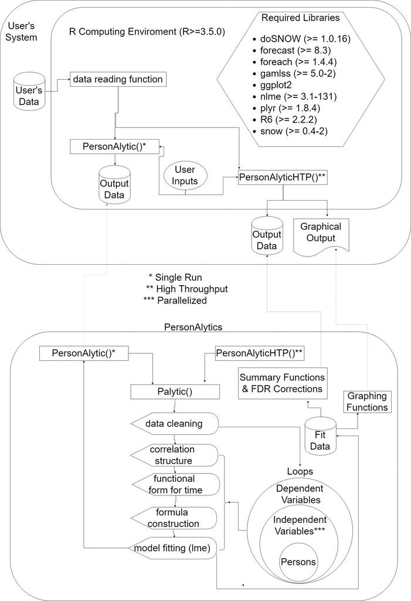

PersonAlytics Design Diagram

### `PersonAlytic()`

**Purpose:** Primary user interface for running one model with one outcome for one subset of the data.

**Inputs:** See *Usage* and *Arugments* in `?PersonAlytic` in `R`.

**Outputs:** See *Value* in `?PersonAlytic` in `R`.

**Called by:** The user in an `R` session where `PersonAlytics` and its required dependencies are loaded.

**Algorithm:** -

- Create `Palytic` object
- If requested, automatically detect the (residual) correlation structure
- If requested, automatically detect the polynomial relationship between time and the dependent variable
- Fit the model implied by the user inputs using using `nlme`

### `Palytic` Class Generator

**Purpose:** Store and validate data and user inputs

**Inputs:** See *Usage* and *Arugments* in `?Palytic` in `R`.

**Outputs:** Outputs are saved back to the `Palytic` object which are extracted by `Palytic` methods or the `PersonAlytic()`, `PersonAlyticHTP()`, or `htp.foreach()` functions.

**Methods:** See *Methods* in `?Palytic` in `R`. These include -

- `lme` for fitting linear mixed effects models to the requested subset of data:
  - Try fitting the model with default settings, if that fails
  - Try fitting the model with using the `optim` optimizer, if that fails
  - Try fitting the model without the random slopes or residual correlation structure, if that fails
  - Return that the “Model did not converge”
- `gamlss` for fitting generalized additive models for location, scale and shape to the requested subset of data:
  - Try fitting the model with default settings, if that fails
  - Try fitting the model with additional cycles, if that fails
  - Try fitting the model without the random slopes, if that fails
  - Return that the “Model did not converge”
- `getAR_order` and `GroupAR_order` for automatically detecting the `ARMA()` order for all participants or for the full sample, respectively:
  - Check whether time is equally spaced, if yes
    - Use the `auto.arima` function of the [forecast](https://cran.r-project.org/web/packages/forecast/index.html) package to detect the best fitting `ARMA` model for autocerrelation.
  - If time is not equally spaced, fit `lme` models up to the maximum specified `p` and `q` for `ARMA(p,q)` and compare models using either LRT or IC as requested.
  - Set the `correlation` or `corStructs` values of the `Palytic` object.
- `getTime_Power` and `GroupTime_power` for automatically detecting the polynomial for the relationship between time and the dependent variable for all participants or for the full sample, respectively:
  - Fit `lme` models up the largest power of time specified by the user.
  - Set the `time_power` or `time_powers` values of the `Palytic` object.

**Called by:** The `PersonAlytic()`, `PersonAlyticHTP()`, or `htp.foreach()` functions.

**Active bindings:** Any time a `Palytic` object is updated (e.g., when iterating over depedent variables), data and inputs are revalidated and formulae are updated.

**Algorithm:** -

- Clean and validate data.
- Create formulae implied by the user inputs to `PersonAlytic()` or `PersonAlyticHTP()`.
- Check whether time is monotonically increasing.
- Create the `Palatyic` class object.

### `PersonAlyticHTP()`

**Purpose:** Primary user interface for running models iterating across multiple outcomes (dependent variables), target independent variables, or individuals.

**Inputs:** See *Fields* in `?PersonAlyticHTP` in `R`.

**Outputs:** See *Value* in `?PersonAlyticHTP` in `R`.

**Called by:** The user in an `R` session where `PersonAlytics` and its required dependencies are loaded.

**Algorithm:** -

- Pre-check data and inputs
- Create iterator lists for dependent variables, independent variables, and individuals
- Send inputs, data, and iterator lists to `htp.foreach()`
- Post-estimation output checks
- Write output data to a `csv` file
- If requested, apply FDR corrections using `psuite()`

### `htp.foreach()`

**Purpose:** Function for running models iterating across multiple outcomes (dependent variables), target independent variables, or individuals.

**Inputs:** See *Fields* in `?PersonAlyticHTP` in `R`.

**Outputs:** See *Value* in `?PersonAlyticHTP` in `R`.

**Called by:** `PersonAlyticsHTP`.

**Algorithm:** -

- Start outer loop for dependent variables
- Set up NULL `Palytic` object
- Call `getAR_order()` or `GroupAR_order()` (see `Palytic` methods above).
- Call `getTime_power()` or `GroupTime_power()` (see `Palytic` methods above).
- Initialize parallelization.
- Start parallelized middle loop for target independent variables.
- Copy the NULL `Palytic` object and add the target independent variable.
- Start the inner loop for participant
  - Determine the subset of data corresponding to the current participant.
  - Extract identifying inputs for labeling outputs.
  - Participant level data validations.
  - Fit the model to the data (see the `lme` and `gamlss` methods for `Palytic` objects).
  - Accumulate model outputs.
- Restructure outputs across the three loops.
- Return outputs as a rectangular data frame to `PersonAlyticsHTP()`.

## Design Rationale

Combining functional programming and OOP was intentional. Many intendend users of `PersonAlytics` will be `R` novices and most basic advice on using `R` is design on showing users how to interact with functions. Hence the user interfacing functions `PersonAlytic()` and `PersonAlyticHTP()` are design to follow this expectation. Although all single analyses can be run using `PersonAlyticHTP()`, it invokes computational overhead for parralellizing R which is avoided using `PersonAlytic()`.

The underlying `Palytic` class was designed in the `R6` OOP framework which is ideal for combining user inputs, data and input validation, active bindings, and methods in an extensible framework.

# Data Design

## Data Description

Users import rectangular research data into R and provide their inputs to `PersonAlytic` or `PersonAlyticHTP`.

## Output Data

The `PersonAlytic` function returns an `lme` or `gamlss` object to the R console. The `PersonAlyticHTP` function saves a `csv` file where each row represents a unique combination of dependent variable, target indepent variable, and individuals. The file has the following columns:

- dv: The name of the dependent variable.
- ivs: The names of the non-target independent variables (i.e., those that do not change across rows).
- target_iv: the name of the target independent variable (i.e., the independent variable that can change across rows).
- fixed: the fixed effects model formula used by `lme`.
- random: the random effects model formula used by `lme`.
- correlation: the residual correlation structure used by `lme`.
- formula: the fixed, random, and correlation formulae used by `gamlss`.
- directory: the working director for the R session in which the `cvs` file is saved.
- date: the date and time in yyyy-mm-dd h:mm:ss format
- *ids*: the numeric values of the user input `ids`.
- ids: the character value of the user variable names assigned to `ids`.
- ivsl: redundant with target_iv, depricate.
- time_power: the value of the `time_power` variable.
- Nobs: the number of observations in the analysis.
- dvVar: the variance of the dependent variable.
- ivVars: flags for non-zero variance of the independent variables.
- converge: convergence status.
- [additional columns with parameters estimates, standard errors, degrees of freedom, t-values, and p-values; column labels depend on the analysis and model].